# R Programming Problems

Ashik E Elahi

2024-02-19

#### Problem 1:

##### For a = 5, b = 15 and c = 10, find

##### (i) $\frac{a+b}{c}$,

##### (ii) $\frac{-b+\sqrt{b^2-4ac}}{2a}$,

##### (iii) $ac+|c-b|$,

##### (iv) $(2a-c)^2$

```r
a = 5; b = 15; c = 10
# (i)
(a+b)/c
```

```
## [1] 2
```

```r
# (ii)
(-b+sqrt(b^2 - 4*a*c))/ (2*a)
```

```
## [1] -1
```

```r
# (iii)
a*c + abs(c-b)
```

```
## [1] 55
```

```r
# (iv)
(2*a-c)^2
```

```
## [1] 0
```

#### Problem 2

##### (i) Create a data vector in R for 20, 13, 14, 25, 16, 20, 10, 9, 23, 35, 70, 12, 15, 13, 10. Manupulate the data vector by removing 70.

##### (ii) Create a data vector in R which is 1 to 15.

##### (iii) Create a data vector in R which 1 to 24 by 2.

##### (iv) Create a following data matrix in R

$$\begin{bmatrix}
1 & 2 & 3 & 4\\
5 & 6 & 7 & 8\\
9 & 10 & 11 & 12
\end{bmatrix}$$
Also find (a) row sum, (b) column sum, and (c) the element in (2, 3) position.

```r
# (i) Removing element from data vector
x <- c(20, 13, 14, 25, 16, 20, 10, 9, 23, 35, 70, 12, 15, 13, 10)
x <- x[-11]
print(x)
```

```
##  [1] 20 13 14 25 16 20 10  9 23 35 12 15 13 10
```

```r
#(ii) Data vector (1 to 15)
x2 <- 1:15
print(x2)
```

```
##  [1]  1  2  3  4  5  6  7  8  9 10 11 12 13 14 15
```

```r
#(iii) Data vector (1 to 24 by 2)
x3 <- seq(1, 24, 2)
print(x3)
```

```
##  [1]  1  3  5  7  9 11 13 15 17 19 21 23
```

```r
#(iv) Matrix
A <- matrix(1:12, nrow = 3, byrow = T)
print(A)
```

```
##      [,1] [,2] [,3] [,4]
## [1,]    1    2    3    4
## [2,]    5    6    7    8
## [3,]    9   10   11   12
```

```r
# (a) Row Sums
rowSums(A)
```

```
## [1] 10 26 42
```

```r
# (b) Columns Sums
colSums(A)
```

```
## [1] 15 18 21 24
```

```r
# (c) Element at (2, 3) position
A[2, 3]
```

```
## [1] 7
```

#### Problem 3

##### (i) Create the following data matrix in R:

$$A =
\begin{bmatrix}
1 & 2 & 3\\
5 & 6 & 7\\
9 & 10 & 11
\end{bmatrix}$$

##### (a) Transpose of A.

##### (b) Find the inverse of A, and

##### (c) Eigen values of A

##### (ii) Consider another matrix

$$B =
\begin{bmatrix}
7 & 4 & 1\\
5 & 6 & 7\\
2 & 7 & 3
\end{bmatrix}$$

##### (a) Find A + B, A - B

##### (b) Find A x B

```r
# (i) First matrix
A <- matrix(1:12, 3, 4, T)
A <- A[, -4]

print(A)
```

```
##      [,1] [,2] [,3]
## [1,]    1    2    3
## [2,]    5    6    7
## [3,]    9   10   11
```

```r
# (a) Transpose of A
t(A)
```

```
##      [,1] [,2] [,3]
## [1,]    1    5    9
## [2,]    2    6   10
## [3,]    3    7   11
```

```r
# (b) Find the inverse of A
# solve(A) ---->>> It shows an error

# (c) Eigen values of A
eigen(A)
```

```
## eigen() decomposition
## $values
## [1]  1.924695e+01 -1.246951e+00  9.342684e-17
##
## $vectors
##           [,1]        [,2]       [,3]
## [1,] 0.1937289  0.77433837  0.4082483
## [2,] 0.5145185  0.07288936 -0.8164966
## [3,] 0.8353082 -0.62855964  0.4082483
```

```r
# (ii) Second Matrix (B)
B <- matrix(c(7, 5, 2, 4, 6, 7, 1, 7, 3), 3, 3)

A + B
```

```
##      [,1] [,2] [,3]
## [1,]    8    6    4
## [2,]   10   12   14
## [3,]   11   17   14
```

```r
A - B
```

```
##      [,1] [,2] [,3]
## [1,]   -6   -2    2
## [2,]    0    0    0
## [3,]    7    3    8
```

```r
# (b) A*B
A %*% B
```

```
##      [,1] [,2] [,3]
## [1,]   23   37   24
## [2,]   79  105   68
## [3,]  135  173  112
```

#### Problem 4

##### Consider the simple fictitious dataset that describe patient responses to two drugs at five dosage level as given below.

| Dosage | Response to Drug A | Response to Drug B |
| --- | --- | --- |
| 20 | 16 | 15 |
| 30 | 20 | 18 |
| 40 | 27 | 25 |
| 45 | 40 | 31 |
| 60 | 60 | 40 |

##### Plot response of the two drugs against dosage. [Add title, legend, text of axes, and set of a reference line at 30]

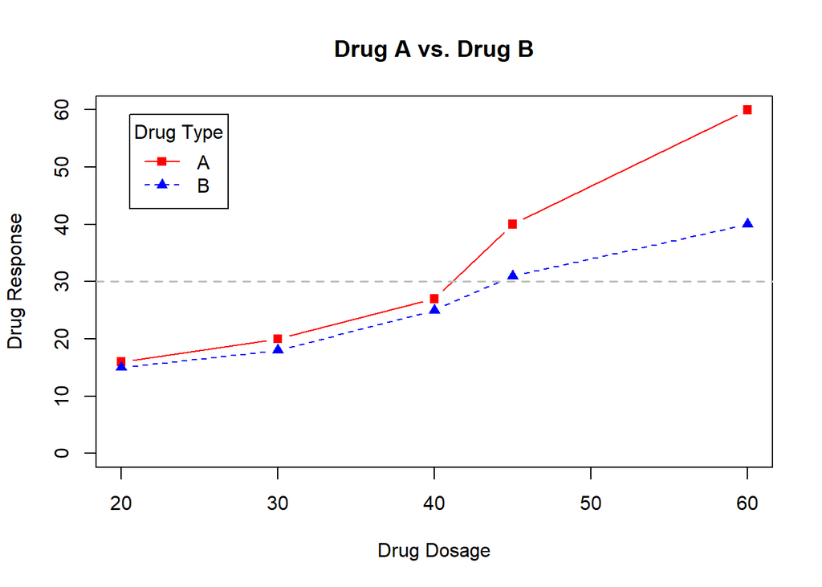

```r
dosage <- c(20, 30, 40, 45, 60)
drugA <- c(16, 20, 27, 40, 60)
drugB <- c(15, 18, 25, 31, 40)

plot(dosage, drugA, type="b", pch=15, lty=1, col="red",
     ylim = c(0, 60), main = "Drug A vs. Drug B",
     xlab ="Drug Dosage", ylab = "Drug Response")
lines(dosage, drugB, type = "b", pch=17, lty=2, col="blue")
abline(h=c(30), lwd=1.5, lty=2, col="gray")
legend("topleft", inset = 0.05, title = "Drug Type", c("A", "B"), lty=c(1, 2), col = c("red", "blue"), pch = c(15, 17))
```

#### Problem 5

##### (i) Use Newton’s method for finding root: $f(x)=x^3+2x^2-7$

##### (ii) Solve the quadratic equation $x^2+2x-7=0$ using if-else() and repeat()

##### (iii) Write a function to compute n! and hence find 23!

##### (iv) Compute coefficient of variance of the dataset c(5, 6, 2, 8, 5, 9, 2, 4, 8, 3, 1, 9)

```r
# (i) Newton's method for finding root
f <- function(x) x^3 + 2*x^2 - 7
f. <- function(x) 3*x^2 + 4*x


calc_root <- function(x=1, tolerance = 0.0000001) {
  while(abs(f(x)) > tolerance) {
    x <- x - f(x) / f.(x)
  }
  return(x)
}

tolerance = 0.0000001
calc_root(x=1, tolerance)
```

```
## [1] 1.428818
```

```r
# Solve the quadratic equation using if-else (x^2 + 2*x-7=0)
a = 1; b = 2; c = -7
root_1 = root_2 = NULL
dis = b^2 - 4*a*c

if(dis < 0) {
  cat("Roots are imaginary\n")
  dis = dis + 0i  # converting into complex form
}

root_1 = (-b + sqrt(dis))/(2*a)
root_2 = (-b - sqrt(dis))/(2*a)

cat("The roots are", round(root_1, 2), "and", round(root_2, 2), "\n")
```

```
## The roots are 1.83 and -3.83
```

```r
# Solve the function using repeat()
g <- function(x) x^2  + 2*x - 7
g. <- function(x) 2*x + 2
calc_root2 <- function(x=1, tolerance = 0.0000001) {
  repeat{
    if(abs(g(x)) < tolerance) {
      break
    }
    x <- x - g(x)/g.(x)
  }
  return(x)
}

root_1 = calc_root2(x=1, tolerance)
root_2 = calc_root2(x=-4, tolerance)

cat("The roots are", round(root_1, 2), "and", round(root_2, 2), "\n")
```

```
## The roots are 1.83 and -3.83
```

```r
# (iii)
fact <- function(n) ifelse(n == 0, 1, prod(1:n))
fact(23)
```

```
## [1] 2.585202e+22
```

```r
# (iv) Compute coefficient of variance
y <- c(5, 6, 2, 8, 5, 9, 2, 4, 8, 3, 1, 9)

cv = sd(y) / mean(y)
cat("Coefficient of variation is ", cv)
```

```
## Coefficient of variation is  0.5525973
```

#### Problem 6

##### Access the default data file “stackloss” in R and fit a simple linear regression of stack.loss on Air.Flow and fitted regression line together and interpret.

```r
head(stackloss)
```

```
##   Air.Flow Water.Temp Acid.Conc. stack.loss
## 1       80         27         89         42
## 2       80         27         88         37
## 3       75         25         90         37
## 4       62         24         87         28
## 5       62         22         87         18
## 6       62         23         87         18
```

```r
attach(stackloss)
# stack.loss = a + b*Air.Flow
fit1 <- lm(stack.loss ~ Air.Flow)
fit1
```

```
##
## Call:
## lm(formula = stack.loss ~ Air.Flow)
##
## Coefficients:
## (Intercept)     Air.Flow
##      -44.13         1.02
```

```r
summary(fit1)
```

```
##
## Call:
## lm(formula = stack.loss ~ Air.Flow)
##
## Residuals:
##      Min       1Q   Median       3Q      Max
## -12.2896  -1.1272  -0.0459   1.1166   8.8728
##
## Coefficients:
##              Estimate Std. Error t value Pr(>|t|)
## (Intercept) -44.13202    6.10586  -7.228 7.31e-07 ***
## Air.Flow      1.02031    0.09995  10.208 3.77e-09 ***
## ---
## Signif. codes:  0 '***' 0.001 '**' 0.01 '*' 0.05 '.' 0.1 ' ' 1
##
## Residual standard error: 4.098 on 19 degrees of freedom
## Multiple R-squared:  0.8458, Adjusted R-squared:  0.8377
## F-statistic: 104.2 on 1 and 19 DF,  p-value: 3.774e-09
```

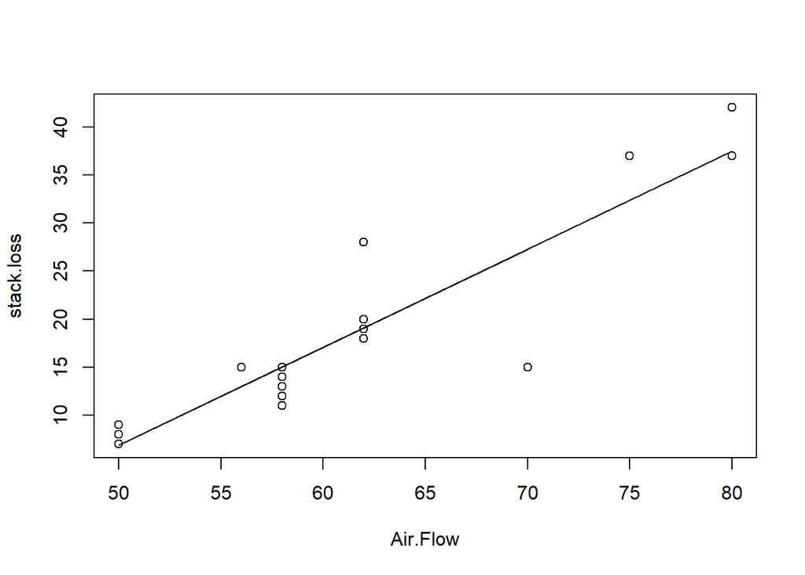

```r
plot(Air.Flow, stack.loss)
lines(Air.Flow, fitted(fit1))
```

#### Problem 7

##### Access the default data file “stackloss” in R and fit a simple linear regression of stack.loss on Water.Temp and fitted regression line together and interpret.

```r
head(stackloss)
```

```
##   Air.Flow Water.Temp Acid.Conc. stack.loss
## 1       80         27         89         42
## 2       80         27         88         37
## 3       75         25         90         37
## 4       62         24         87         28
## 5       62         22         87         18
## 6       62         23         87         18
```

```r
attach(stackloss)
# stack.loss = a + b*Water.Temp
fit2 <- lm(stack.loss ~ Water.Temp)
fit2
```

```
##
## Call:
## lm(formula = stack.loss ~ Water.Temp)
##
## Coefficients:
## (Intercept)   Water.Temp
##     -41.911        2.817
```

```r
summary(fit2)
```

```
##
## Call:
## lm(formula = stack.loss ~ Water.Temp)
##
## Residuals:
##     Min      1Q  Median      3Q     Max
## -7.8904 -3.6206  0.3794  2.8398  8.4747
##
## Coefficients:
##             Estimate Std. Error t value Pr(>|t|)
## (Intercept) -41.9109     7.6056  -5.511 2.58e-05 ***
## Water.Temp    2.8174     0.3567   7.898 2.03e-07 ***
## ---
## Signif. codes:  0 '***' 0.001 '**' 0.01 '*' 0.05 '.' 0.1 ' ' 1
##
## Residual standard error: 5.043 on 19 degrees of freedom
## Multiple R-squared:  0.7665, Adjusted R-squared:  0.7542
## F-statistic: 62.37 on 1 and 19 DF,  p-value: 2.028e-07
```

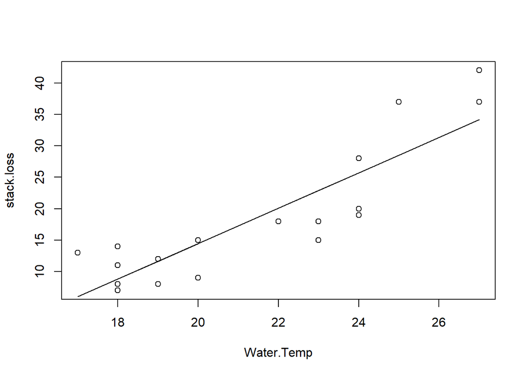

```r
plot(Water.Temp, stack.loss)
lines(Water.Temp, fitted(fit2))
```